# 06 Interpretable Rule Extraction

This notebook aims to extract simple, human-readable rules from the Phase 2 dataset.

The goal is not to improve prediction accuracy, but to simplify the descriptor space and identify interpretable regimes associated with hydrovoltaic performance.

```python
import numpy as np
import pandas as pd
import matplotlib.pyplot as plt

from sklearn.tree import DecisionTreeRegressor, DecisionTreeClassifier, plot_tree, export_text
from sklearn.model_selection import StratifiedShuffleSplit, cross_validate
from sklearn.compose import ColumnTransformer
from sklearn.pipeline import Pipeline
from sklearn.impute import SimpleImputer
from sklearn.preprocessing import OneHotEncoder
from sklearn.metrics import r2_score
```

```python
# Load data and define variables
df = pd.read_csv(
    "../data/processed/hydrovoltaic_dataset_phase2_input_utf8.csv",
    encoding="utf-8-sig"
)

TARGET = "log_estimated_power_density"
STRATIFY_COL = "mechanism_simple"
GROUP_COL = "paper_doi"

FEATURES_MODEL_A = [
    "material_class",
    "structure_class",
    "built_in_asymmetry",
    "inorganic_electrolyte_present",
    "polyelectrolyte_present",
    "has_anionic",
    "has_cationic",
    "has_zwitterionic",
    "mechanism_simple",
    "water_interaction_mode",
    "top_electrode",
    "bottom_electrode",
    "electrode_symmetry",
    "metal_electrode",
    "ionic_groups",
    "ion_type"
]

FEATURES_MODEL_B = FEATURES_MODEL_A + [
    "log_internal_resistance_Mohm",
    "has_internal_resistance"
]

df_rules = df.dropna(subset=[TARGET, STRATIFY_COL]).copy()

X = df_rules[FEATURES_MODEL_B]
y = df_rules[TARGET]

print("Rows:", df_rules.shape[0])
print("Features:", len(FEATURES_MODEL_B))
print(df_rules[STRATIFY_COL].value_counts(dropna=False))
```

```
Rows: 159
Features: 18
mechanism_simple
ion_gradient    107
streaming        52
Name: count, dtype: int64
```

```python
# Preprocessor
def build_preprocessor(df_input, features):
    numeric_features = []
    categorical_features = []

    for col in features:
        if pd.api.types.is_numeric_dtype(df_input[col]):
            numeric_features.append(col)
        else:
            categorical_features.append(col)

    numeric_transformer = Pipeline(steps=[
        ("imputer", SimpleImputer(strategy="median"))
    ])

    categorical_transformer = Pipeline(steps=[
        ("imputer", SimpleImputer(strategy="most_frequent")),
        ("onehot", OneHotEncoder(handle_unknown="ignore", sparse_output=False))
    ])

    preprocessor = ColumnTransformer(
        transformers=[
            ("num", numeric_transformer, numeric_features),
            ("cat", categorical_transformer, categorical_features)
        ],
        remainder="drop"
    )

    return preprocessor
```

```python
# Encode features for rule extraction
preprocessor = build_preprocessor(df_rules, FEATURES_MODEL_B)

X_encoded = preprocessor.fit_transform(X)

feature_names = preprocessor.get_feature_names_out()

X_encoded_df = pd.DataFrame(
    X_encoded,
    columns=feature_names,
    index=df_rules.index
)

print("Encoded shape:", X_encoded_df.shape)
X_encoded_df.head()
```

```
Encoded shape: (159, 104)
```

|  | num__built_in_asymmetry | num__inorganic_electrolyte_present | num__polyelectrolyte_present | num__has_anionic | num__has_cationic | num__has_zwitterionic | num__electrode_symmetry | num__metal_electrode | num__log_internal_resistance_Mohm | num__has_internal_resistance | ... | cat__ionic_groups_sulfonate, amino | cat__ionic_groups_sulfonate, carboxyl, hydroxyl | cat__ionic_groups_sulfonate, carboxyl, hydroxyl | cat__ionic_groups_sulfonate, hydroxyl | cat__ionic_groups_sulfonate, phosphate, hydroxyl | cat__ionic_groups_sulfonate, quaternary ammonium, hydroxyl | cat__ionic_groups_titanol | cat__ion_type_anion | cat__ion_type_other_cation | cat__ion_type_proton |
| --- | --- | --- | --- | --- | --- | --- | --- | --- | --- | --- | --- | --- | --- | --- | --- | --- | --- | --- | --- | --- | --- |
| 0 | 0.0 | 0.0 | 0.0 | 0.0 | 0.0 | 0.0 | 1.0 | 0.0 | 0.903090 | 1.0 | ... | 0.0 | 0.0 | 0.0 | 0.0 | 0.0 | 0.0 | 0.0 | 0.0 | 0.0 | 1.0 |
| 1 | 0.0 | 0.0 | 0.0 | 0.0 | 0.0 | 0.0 | 1.0 | 1.0 | 1.535294 | 1.0 | ... | 0.0 | 0.0 | 0.0 | 0.0 | 0.0 | 0.0 | 0.0 | 1.0 | 0.0 | 0.0 |
| 2 | 1.0 | 0.0 | 0.0 | 0.0 | 0.0 | 0.0 | 1.0 | 0.0 | 1.778151 | 1.0 | ... | 0.0 | 0.0 | 0.0 | 0.0 | 0.0 | 0.0 | 0.0 | 1.0 | 0.0 | 0.0 |
| 3 | 0.0 | 0.0 | 0.0 | 0.0 | 0.0 | 0.0 | 1.0 | 0.0 | -0.903438 | 0.0 | ... | 0.0 | 0.0 | 0.0 | 0.0 | 0.0 | 0.0 | 0.0 | 0.0 | 0.0 | 1.0 |
| 4 | 0.0 | 0.0 | 0.0 | 0.0 | 0.0 | 0.0 | 1.0 | 0.0 | -0.903438 | 0.0 | ... | 0.0 | 0.0 | 0.0 | 0.0 | 0.0 | 0.0 | 0.0 | 0.0 | 0.0 | 1.0 |

5 rows × 104 columns

## 06.1 Simple regression tree

A shallow decision tree is used to extract simple rules associated with power density. The tree depth is intentionally limited to avoid overfitting and to keep the rules interpretable.

```python
# Fit shallow regression tree
tree_reg = DecisionTreeRegressor(
    max_depth=3,
    min_samples_leaf=10,
    random_state=42
)

tree_reg.fit(X_encoded_df, y)

print("Training R2:", tree_reg.score(X_encoded_df, y))
```

```
Training R2: 0.4231042211946082
```

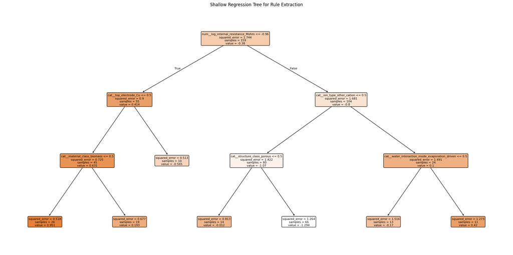

```python
# Plot regression tree
plt.figure(figsize=(20, 10))

plot_tree(
    tree_reg,
    feature_names=feature_names,
    filled=True,
    rounded=True,
    fontsize=8
)

plt.title("Shallow Regression Tree for Rule Extraction")
plt.tight_layout()
plt.show()
```

```python
# Print text rules
rules_text = export_text(
    tree_reg,
    feature_names=list(feature_names),
    decimals=3
)

print(rules_text)
```

```
|--- num__log_internal_resistance_Mohm <= -0.960
|   |--- cat__top_electrode_Cu <= 0.500
|   |   |--- cat__material_class_biomass <= 0.500
|   |   |   |--- value: [0.951]
|   |   |--- cat__material_class_biomass >  0.500
|   |   |   |--- value: [0.193]
|   |--- cat__top_electrode_Cu >  0.500
|   |   |--- value: [-0.565]
|--- num__log_internal_resistance_Mohm >  -0.960
|   |--- cat__ion_type_other_cation <= 0.500
|   |   |--- cat__structure_class_porous <= 0.500
|   |   |   |--- value: [-0.012]
|   |   |--- cat__structure_class_porous >  0.500
|   |   |   |--- value: [-1.294]
|   |--- cat__ion_type_other_cation >  0.500
|   |   |--- cat__water_interaction_mode_evaporation_driven <= 0.500
|   |   |   |--- value: [-0.170]
|   |   |--- cat__water_interaction_mode_evaporation_driven >  0.500
|   |   |   |--- value: [0.420]
```

Rule-based high/low classification

## 06.2 High-power vs low-power rule tree

To further simplify the interpretation, the continuous target is converted into high-power and low-power classes using the median power density as the threshold.

```python
# Create high/low target
threshold = y.median()

df_rules["power_class"] = np.where(
    df_rules[TARGET] >= threshold,
    "high_power",
    "low_power"
)

y_class = (df_rules[TARGET] >= threshold).astype(int)

print("Threshold:", threshold)
print(df_rules["power_class"].value_counts())
```

```
Threshold: -0.2819128740320925
power_class
high_power    80
low_power     79
Name: count, dtype: int64
```

```python
# Fit shallow classifier tree
tree_clf = DecisionTreeClassifier(
    max_depth=3,
    min_samples_leaf=10,
    random_state=42
)

tree_clf.fit(X_encoded_df, y_class)

print("Training accuracy:", tree_clf.score(X_encoded_df, y_class))
```

```
Training accuracy: 0.7924528301886793
```

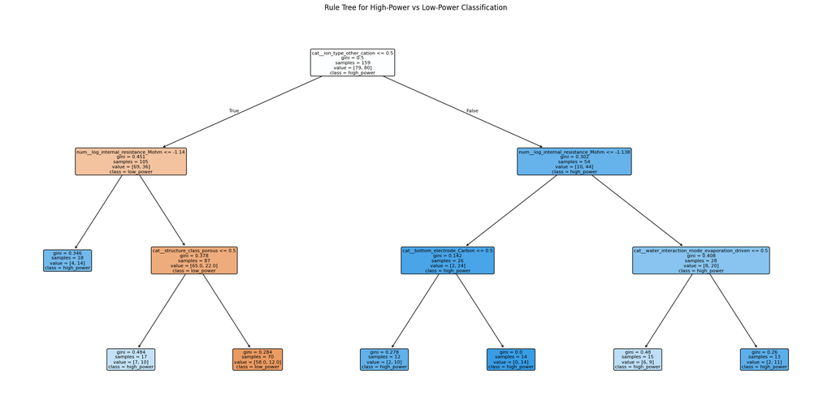

```python
# Plot classifier tree
plt.figure(figsize=(20, 10))

plot_tree(
    tree_clf,
    feature_names=feature_names,
    class_names=["low_power", "high_power"],
    filled=True,
    rounded=True,
    fontsize=8
)

plt.title("Rule Tree for High-Power vs Low-Power Classification")
plt.tight_layout()
plt.show()
```

```python
# Print classifier rules
class_rules_text = export_text(
    tree_clf,
    feature_names=list(feature_names),
    decimals=3
)

print(class_rules_text)
```

```
|--- cat__ion_type_other_cation <= 0.500
|   |--- num__log_internal_resistance_Mohm <= -1.140
|   |   |--- class: 1
|   |--- num__log_internal_resistance_Mohm >  -1.140
|   |   |--- cat__structure_class_porous <= 0.500
|   |   |   |--- class: 1
|   |   |--- cat__structure_class_porous >  0.500
|   |   |   |--- class: 0
|--- cat__ion_type_other_cation >  0.500
|   |--- num__log_internal_resistance_Mohm <= -1.138
|   |   |--- cat__bottom_electrode_Carbon <= 0.500
|   |   |   |--- class: 1
|   |   |--- cat__bottom_electrode_Carbon >  0.500
|   |   |   |--- class: 1
|   |--- num__log_internal_resistance_Mohm >  -1.138
|   |   |--- cat__water_interaction_mode_evaporation_driven <= 0.500
|   |   |   |--- class: 1
|   |   |--- cat__water_interaction_mode_evaporation_driven >  0.500
|   |   |   |--- class: 1
```

## 06.3 Regime summary based on extracted rules

The decision tree rules are converted into simple regime labels to compare the target distribution across interpretable groups.

```python
# Add predicted regimes from classifier tree
df_rules["tree_regime"] = tree_clf.predict(X_encoded_df)

df_rules["tree_regime"] = df_rules["tree_regime"].map({
    0: "low_power_regime",
    1: "high_power_regime"
})

regime_summary = (
    df_rules
    .groupby("tree_regime")[TARGET]
    .agg(["count", "mean", "std", "min", "max"])
    .reset_index()
)

regime_summary
```

|  | tree_regime | count | mean | std | min | max |
| --- | --- | --- | --- | --- | --- | --- |
| 0 | high_power_regime | 89 | 0.295833 | 1.009424 | -2.606249 | 2.916454 |
| 1 | low_power_regime | 70 | -1.239598 | 1.174846 | -4.283997 | 2.139879 |

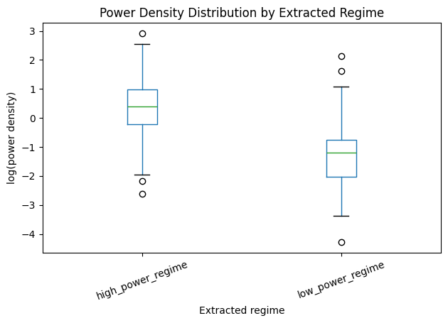

```python
# Boxplot of extracted regimes
plt.figure(figsize=(6, 4))

df_rules.boxplot(
    column=TARGET,
    by="tree_regime",
    grid=False
)

plt.suptitle("")
plt.title("Power Density Distribution by Extracted Regime")
plt.xlabel("Extracted regime")
plt.ylabel("log(power density)")
plt.xticks(rotation=20)

plt.tight_layout()
plt.show()
```

Simple physical regime check

## 06.4 Manually defined physical regimes

Based on previous robustness results, structure and internal resistance are tested as simple physical regime descriptors.

```python
# Define low/high resistance regime
r_col = "log_internal_resistance_Mohm"

r_threshold = df_rules[r_col].median()

df_rules["R_regime"] = np.where(
    df_rules[r_col] <= r_threshold,
    "low_R",
    "high_R"
)

print("R threshold:", r_threshold)
print(df_rules["R_regime"].value_counts())
```

```
R threshold: -0.9034377008227692
R_regime
high_R    103
low_R      56
Name: count, dtype: int64
```

```python
# Combine structure and resistance
df_rules["structure_R_regime"] = (
    df_rules["structure_class"].astype(str)
    + "_"
    + df_rules["R_regime"].astype(str)
)

structure_R_summary = (
    df_rules
    .groupby("structure_R_regime")[TARGET]
    .agg(["count", "mean", "std", "min", "max"])
    .sort_values("mean", ascending=False)
    .reset_index()
)

structure_R_summary
```

|  | structure_R_regime | count | mean | std | min | max |
| --- | --- | --- | --- | --- | --- | --- |
| 0 | film_low_R | 7 | 1.406973 | 1.073480 | -0.685604 | 2.552060 |
| 1 | hydrogel + film_low_R | 1 | 1.005909 | NaN | 1.005909 | 1.005909 |
| 2 | hydrogel + porous_low_R | 4 | 0.769556 | 0.362182 | 0.315551 | 1.202079 |
| 3 | hydrogel_low_R | 9 | 0.329380 | 0.762342 | -0.999996 | 1.828144 |
| 4 | film_high_R | 15 | 0.111372 | 0.957789 | -1.258644 | 1.909823 |
| 5 | porous_low_R | 35 | 0.100917 | 0.995890 | -2.315963 | 2.139879 |
| 6 | hydrogel_high_R | 5 | -0.234371 | 0.587971 | -1.163828 | 0.386945 |
| 7 | porous_high_R | 83 | -0.980373 | 1.313841 | -4.283997 | 2.916454 |

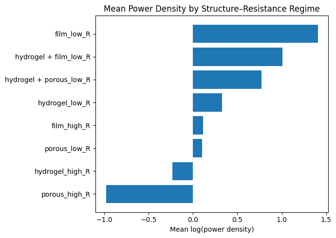

```python
# Plot structure + R regimes
plot_df = structure_R_summary.sort_values("mean", ascending=True)

plt.figure(figsize=(7, 5))

plt.barh(
    plot_df["structure_R_regime"],
    plot_df["mean"]
)

plt.xlabel("Mean log(power density)")
plt.title("Mean Power Density by Structure–Resistance Regime")

plt.tight_layout()
plt.show()
```

```python
# Save outputs
regime_summary.to_csv(
    "../results/phase2_rule_tree_regime_summary.csv",
    index=False,
    encoding="utf-8-sig"
)

structure_R_summary.to_csv(
    "../results/phase2_structure_R_regime_summary.csv",
    index=False,
    encoding="utf-8-sig"
)

print("Saved rule extraction summaries.")
```

```
Saved rule extraction summaries.
```

Rule-based analysis reveals that hydrovoltaic performance can be described by a simple two-regime framework governed primarily by internal resistance and structural characteristics.

Within each regime, structural features such as porosity further modulate performance, indicating that transport pathways play a secondary but important role.

These findings suggest that continuous descriptors capturing system-level transport behavior provide a more reliable representation of hydrovoltaic performance than discrete mechanism classifications.

## 06.6 Explicit descriptor definition

Based on the shallow tree and regime analysis, we define a simplified descriptor using internal resistance and structure. This step converts the learned tree-based patterns into explicit, human-readable regimes.

```python
# Define resistance-based descriptor
# Use a simple threshold close to the tree-derived split
# Tree split was approximately log_internal_resistance_Mohm <= -0.96
r_descriptor_threshold = -1.0

df_rules["R_descriptor"] = np.where(
    df_rules["log_internal_resistance_Mohm"] <= r_descriptor_threshold,
    "low_R_regime",
    "high_R_regime"
)

R_descriptor_summary = (
    df_rules
    .groupby("R_descriptor")[TARGET]
    .agg(["count", "mean", "std", "min", "max"])
    .sort_values("mean", ascending=False)
    .reset_index()
)

R_descriptor_summary
```

|  | R_descriptor | count | mean | std | min | max |
| --- | --- | --- | --- | --- | --- | --- |
| 0 | low_R_regime | 55 | 0.413553 | 0.957220 | -1.528107 | 2.552060 |
| 1 | high_R_regime | 104 | -0.799886 | 1.302834 | -4.283997 | 2.916454 |

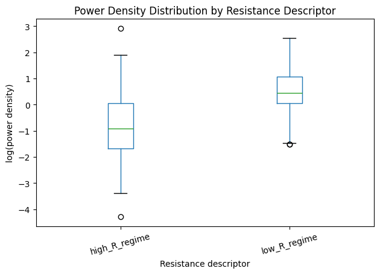

```python
# Plot resistance descriptor
plt.figure(figsize=(6, 4))

df_rules.boxplot(
    column=TARGET,
    by="R_descriptor",
    grid=False
)

plt.suptitle("")
plt.title("Power Density Distribution by Resistance Descriptor")
plt.xlabel("Resistance descriptor")
plt.ylabel("log(power density)")
plt.xticks(rotation=15)

plt.tight_layout()
plt.show()
```

```python
# Define 2D descriptor: structure + resistance
df_rules["structure_R_descriptor"] = (
    df_rules["structure_class"].astype(str)
    + "_"
    + df_rules["R_descriptor"].astype(str)
)

structure_R_descriptor_summary = (
    df_rules
    .groupby("structure_R_descriptor")[TARGET]
    .agg(["count", "mean", "std", "min", "max"])
    .sort_values("mean", ascending=False)
    .reset_index()
)

structure_R_descriptor_summary
```

|  | structure_R_descriptor | count | mean | std | min | max |
| --- | --- | --- | --- | --- | --- | --- |
| 0 | film_low_R_regime | 7 | 1.406973 | 1.073480 | -0.685604 | 2.552060 |
| 1 | hydrogel + film_low_R_regime | 1 | 1.005909 | NaN | 1.005909 | 1.005909 |
| 2 | hydrogel + porous_low_R_regime | 4 | 0.769556 | 0.362182 | 0.315551 | 1.202079 |
| 3 | hydrogel_low_R_regime | 9 | 0.329380 | 0.762342 | -0.999996 | 1.828144 |
| 4 | porous_low_R_regime | 34 | 0.172002 | 0.916317 | -1.528107 | 2.139879 |
| 5 | film_high_R_regime | 15 | 0.111372 | 0.957789 | -1.258644 | 1.909823 |
| 6 | hydrogel_high_R_regime | 5 | -0.234371 | 0.587971 | -1.163828 | 0.386945 |
| 7 | porous_high_R_regime | 84 | -0.996273 | 1.314008 | -4.283997 | 2.916454 |

```python
# Filter small groups for cleaner interpretation
min_group_size = 5

structure_R_descriptor_summary_filtered = (
    structure_R_descriptor_summary
    [structure_R_descriptor_summary["count"] >= min_group_size]
    .copy()
    .sort_values("mean", ascending=False)
)

structure_R_descriptor_summary_filtered
```

|  | structure_R_descriptor | count | mean | std | min | max |
| --- | --- | --- | --- | --- | --- | --- |
| 0 | film_low_R_regime | 7 | 1.406973 | 1.073480 | -0.685604 | 2.552060 |
| 3 | hydrogel_low_R_regime | 9 | 0.329380 | 0.762342 | -0.999996 | 1.828144 |
| 4 | porous_low_R_regime | 34 | 0.172002 | 0.916317 | -1.528107 | 2.139879 |
| 5 | film_high_R_regime | 15 | 0.111372 | 0.957789 | -1.258644 | 1.909823 |
| 6 | hydrogel_high_R_regime | 5 | -0.234371 | 0.587971 | -1.163828 | 0.386945 |
| 7 | porous_high_R_regime | 84 | -0.996273 | 1.314008 | -4.283997 | 2.916454 |

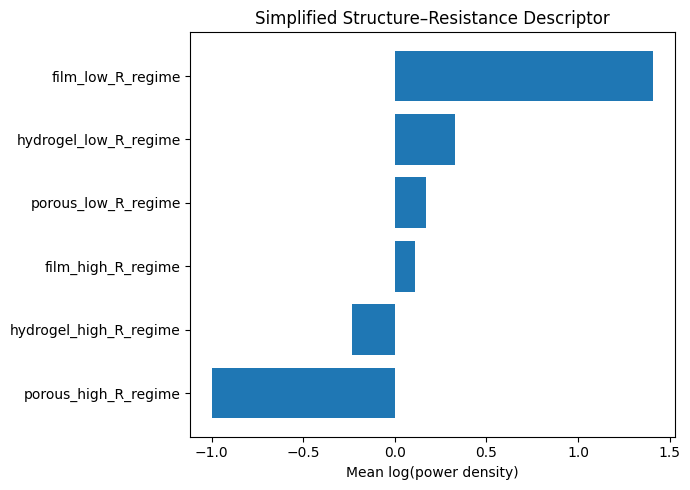

```python
# Plot filtered 2D descriptor
plot_df = structure_R_descriptor_summary_filtered.sort_values("mean", ascending=True)

plt.figure(figsize=(7, 5))

plt.barh(
    plot_df["structure_R_descriptor"],
    plot_df["mean"]
)

plt.xlabel("Mean log(power density)")
plt.title("Simplified Structure–Resistance Descriptor")

plt.tight_layout()
plt.show()
```

```python
# Add simplified high / low rule labels
def assign_simplified_rule(row):
    r_regime = row["R_descriptor"]
    structure = str(row["structure_class"])

    if r_regime == "low_R_regime":
        return "Rule 1: low R → higher power"
    elif r_regime == "high_R_regime" and "porous" in structure:
        return "Rule 2: high R + porous → lower power"
    elif r_regime == "high_R_regime":
        return "Rule 3: high R → lower power"
    else:
        return "Other"

df_rules["simplified_rule"] = df_rules.apply(assign_simplified_rule, axis=1)

rule_summary = (
    df_rules
    .groupby("simplified_rule")[TARGET]
    .agg(["count", "mean", "std", "min", "max"])
    .sort_values("mean", ascending=False)
    .reset_index()
)

rule_summary
```

|  | simplified_rule | count | mean | std | min | max |
| --- | --- | --- | --- | --- | --- | --- |
| 0 | Rule 1: low R → higher power | 55 | 0.413553 | 0.957220 | -1.528107 | 2.552060 |
| 1 | Rule 3: high R → lower power | 20 | 0.024936 | 0.878819 | -1.258644 | 1.909823 |
| 2 | Rule 2: high R + porous → lower power | 84 | -0.996273 | 1.314008 | -4.283997 | 2.916454 |

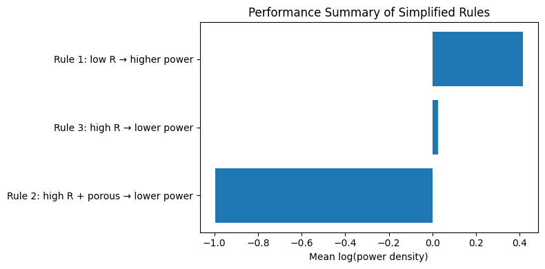

```python
# Plot simplified rule summary
plot_df = rule_summary.sort_values("mean", ascending=True)

plt.figure(figsize=(8, 4))

plt.barh(
    plot_df["simplified_rule"],
    plot_df["mean"]
)

plt.xlabel("Mean log(power density)")
plt.title("Performance Summary of Simplified Rules")

plt.tight_layout()
plt.show()
```

```python
R_descriptor_summary.to_csv(
    "../results/phase2_R_descriptor_summary.csv",
    index=False,
    encoding="utf-8-sig"
)

structure_R_descriptor_summary.to_csv(
    "../results/phase2_structure_R_descriptor_summary.csv",
    index=False,
    encoding="utf-8-sig"
)

structure_R_descriptor_summary_filtered.to_csv(
    "../results/phase2_structure_R_descriptor_summary_filtered.csv",
    index=False,
    encoding="utf-8-sig"
)

rule_summary.to_csv(
    "../results/phase2_simplified_rule_summary.csv",
    index=False,
    encoding="utf-8-sig"
)

print("Saved final descriptor and rule summaries.")
```

```
Saved final descriptor and rule summaries.
```

Structural features further modulate performance within each regime, with film-based structures generally outperforming porous systems under comparable resistance conditions. However, resistance remains the dominant factor governing system behavior.

These results demonstrate that hydrovoltaic performance can be effectively described using a low-dimensional descriptor space defined primarily by internal resistance, with structural characteristics providing secondary refinement.